# Code for ‘The development of canonical proportion continues past toddlerhood’ (ICPhS 2023)

Kasia Hitczenko

April 28, 2023

## 1. Statistical analyses for the ICPhS2023 paper

### a. Regressions studying the relationship between age and canonical proportion

To study how canonical proportion develops through 6 years of age, we compared two models: (1) a mixed effects logistic regression predicting the effect of age on CP, controlling for gender and including corpus in the random effects structure and (2) the same model but instead with age-squared as a predictor. This analysis corresponds to (1) and (2) in the paper.

Output of the linear model:

```
## Generalized linear mixed model fit by maximum likelihood (Laplace
##   Approximation) [glmerMod]
##  Family: binomial  ( logit )
## Formula: cp ~ age_mo_round_z + child_gender + (0 + age_mo_round_z | corpus)
##    Data: df
## Weights: n_speechlike
##
##      AIC      BIC   logLik deviance df.resid
##   2250.1   2261.5  -1121.0   2242.1      125
##
## Scaled residuals:
##     Min      1Q  Median      3Q     Max
## -9.8531 -2.0278  0.3644  1.8414 10.7657
##
## Random effects:
##  Groups Name           Variance Std.Dev.
##  corpus age_mo_round_z 0.283    0.532
## Number of obs: 129, groups:  corpus, 8
##
## Fixed effects:
##                Estimate Std. Error z value Pr(>|z|)
## (Intercept)    -0.42808    0.02190 -19.549  < 2e-16 ***
## age_mo_round_z  1.03977    0.20531   5.064  4.1e-07 ***
## child_genderM  -0.01819    0.02583  -0.704    0.481
## ---
## Signif. codes:  0 '***' 0.001 '**' 0.01 '*' 0.05 '.' 0.1 ' ' 1
##
## Correlation of Fixed Effects:
##             (Intr) ag_m__
## age_m_rnd_z  0.043
## child_gndrM -0.625  0.012
```

Output of the quadratic model:

```
## Generalized linear mixed model fit by maximum likelihood (Laplace
##   Approximation) [glmerMod]
##  Family: binomial  ( logit )
## Formula: cp ~ age_mo_round_sq_z + age_mo_round_z + child_gender + (0 +
##     age_mo_round_z + age_mo_round_sq_z | corpus)
##    Data: df
## Weights: n_speechlike
##
##      AIC      BIC   logLik deviance df.resid
##   2073.4   2093.4  -1029.7   2059.4      122
##
## Scaled residuals:
##     Min      1Q  Median      3Q     Max
## -9.7477 -1.8665  0.0615  1.6615  9.6865
##
## Random effects:
##  Groups Name              Variance Std.Dev. Corr
##  corpus age_mo_round_z    0.09687  0.3112
##         age_mo_round_sq_z 0.15199  0.3899   0.21
## Number of obs: 129, groups:  corpus, 8
##
## Fixed effects:
##                   Estimate Std. Error z value Pr(>|z|)
## (Intercept)       -0.58419    0.02585 -22.596   <2e-16 ***
## age_mo_round_sq_z -0.41497    0.15698  -2.644   0.0082 **
## age_mo_round_z     1.10776    0.12812   8.646   <2e-16 ***
## child_genderM     -0.01781    0.02625  -0.678   0.4975
## ---
## Signif. codes:  0 '***' 0.001 '**' 0.01 '*' 0.05 '.' 0.1 ' ' 1
##
## Correlation of Fixed Effects:
##             (Intr) ag____ ag_m__
## ag_m_rnd_s_  0.094
## age_m_rnd_z  0.070  0.029
## child_gndrM -0.559  0.011 -0.021
```

Comparison between the two models, showing that the quadratic model is a better fit:

```
## Data: df
## Models:
## age.model: cp ~ age_mo_round_z + child_gender + (0 + age_mo_round_z | corpus)
## agesq.model: cp ~ age_mo_round_sq_z + age_mo_round_z + child_gender + (0 + age_mo_round_z + age_mo_round_sq_z | corpus)
##             npar    AIC    BIC  logLik deviance  Chisq Df Pr(>Chisq)
## age.model      4 2250.1 2261.5 -1121.0   2242.1
## agesq.model    7 2073.4 2093.4 -1029.7   2059.4 182.65  3  < 2.2e-16 ***
## ---
## Signif. codes:  0 '***' 0.001 '**' 0.01 '*' 0.05 '.' 0.1 ' ' 1
```

### b. Regression studying the relationship between syllabic complexity and canonical proportion

This corresponds to (3) in the paper. We found a significant main effect of syllabic complexity on canonical proportion and in interaction with both age and age$^2$, meaning that both the rates of learning and plateauing differed depending on the syllabic complexity of the language the children were learning.

```
##
## Call:
## glm(formula = cp ~ age_mo_round_z * syllcomplexity + age_mo_round_sq_z *
##     syllcomplexity, family = binomial(), data = df_syllcomp,
##     weights = n_speechlike)
##
## Deviance Residuals:
##      Min        1Q    Median        3Q       Max
## -10.4389   -1.9793    0.4292    1.6949   10.3621
##
## Coefficients:
##                                          Estimate Std. Error z value Pr(>|z|)
## (Intercept)                              -1.10320    0.05183 -21.284  < 2e-16
## age_mo_round_z                            0.96340    0.06135  15.704  < 2e-16
## syllcomplexityModerate                    0.46228    0.05877   7.865 3.68e-15
## syllcomplexityHigh                        0.15057    0.05798   2.597  0.00940
## age_mo_round_sq_z                        -0.29202    0.05123  -5.701 1.19e-08
## age_mo_round_z:syllcomplexityModerate    -0.72606    0.07082 -10.252  < 2e-16
## age_mo_round_z:syllcomplexityHigh        -0.17715    0.07065  -2.508  0.01216
## syllcomplexityModerate:age_mo_round_sq_z  0.27159    0.05845   4.646 3.38e-06
## syllcomplexityHigh:age_mo_round_sq_z      0.17992    0.06274   2.868  0.00413
##
## (Intercept)                              ***
## age_mo_round_z                           ***
## syllcomplexityModerate                   ***
## syllcomplexityHigh                       **
## age_mo_round_sq_z                        ***
## age_mo_round_z:syllcomplexityModerate    ***
## age_mo_round_z:syllcomplexityHigh        *
## syllcomplexityModerate:age_mo_round_sq_z ***
## syllcomplexityHigh:age_mo_round_sq_z     **
## ---
## Signif. codes:  0 '***' 0.001 '**' 0.01 '*' 0.05 '.' 0.1 ' ' 1
##
## (Dispersion parameter for binomial family taken to be 1)
##
##     Null deviance: 3012.4  on 101  degrees of freedom
## Residual deviance: 1369.6  on  93  degrees of freedom
## AIC: 1861.6
##
## Number of Fisher Scoring iterations: 5
```

```
## Analysis of Deviance Table (Type III tests)
##
## Response: cp
##                                  LR Chisq Df Pr(>Chisq)
## age_mo_round_z                     371.32  1  < 2.2e-16 ***
## syllcomplexity                      96.19  2  < 2.2e-16 ***
## age_mo_round_sq_z                   34.79  1  3.674e-09 ***
## age_mo_round_z:syllcomplexity      169.73  2  < 2.2e-16 ***
## syllcomplexity:age_mo_round_sq_z    22.72  2  1.167e-05 ***
## ---
## Signif. codes:  0 '***' 0.001 '**' 0.01 '*' 0.05 '.' 0.1 ' ' 1
```

### c. Regression studying the relationship between community (urban vs. rural) and canonical proportion

Here, we found a significant main effect of community on canonical proportion, but no interaction effects with age or age$^2$, suggesting that children raised in rural environments may have higher canonical proportions than those raised in urban environments, but show similar developmental patterns (i.e., slopes and plateaus). This corresponds to the analysis described at the end of p.3 of the paper.

```
##
## Call:
## glm(formula = cp ~ age_mo_round_z * urbrur + age_mo_round_sq_z *
##     urbrur, family = binomial(), data = df_urbrur, weights = n_speechlike)
##
## Deviance Residuals:
##      Min        1Q    Median        3Q       Max
## -10.9192   -3.5933    0.3518    1.3454   10.6324
##
## Coefficients:
##                               Estimate Std. Error z value Pr(>|z|)
## (Intercept)                   -0.98442    0.03307 -29.766  < 2e-16 ***
## age_mo_round_z                 0.20974    0.02549   8.228  < 2e-16 ***
## urbrurUrban                   -0.23203    0.04072  -5.698 1.21e-08 ***
## age_mo_round_sq_z              0.06272    0.02833   2.214   0.0268 *
## age_mo_round_z:urbrurUrban     0.03371    0.03607   0.935   0.3500
## urbrurUrban:age_mo_round_sq_z -0.02701    0.03737  -0.723   0.4698
## ---
## Signif. codes:  0 '***' 0.001 '**' 0.01 '*' 0.05 '.' 0.1 ' ' 1
##
## (Dispersion parameter for binomial family taken to be 1)
##
##     Null deviance: 1290.1  on 64  degrees of freedom
## Residual deviance: 1063.2  on 59  degrees of freedom
## AIC: 1377.1
##
## Number of Fisher Scoring iterations: 4
```

```
## Analysis of Deviance Table (Type III tests)
##
## Response: cp
##                          LR Chisq Df Pr(>Chisq)
## age_mo_round_z             69.155  1  < 2.2e-16 ***
## urbrur                     32.046  1  1.505e-08 ***
## age_mo_round_sq_z           4.889  1    0.02702 *
## age_mo_round_z:urbrur       0.874  1    0.34989
## urbrur:age_mo_round_sq_z    0.523  1    0.46967
## ---
## Signif. codes:  0 '***' 0.001 '**' 0.01 '*' 0.05 '.' 0.1 ' ' 1
```

## 2. Figure 1 from the ICPhS2023 paper

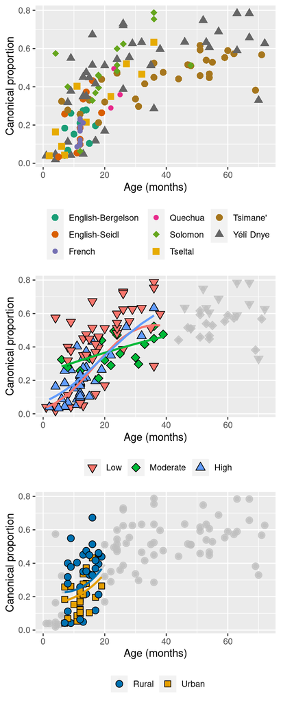

## 3. BUCLD Plots

This work was first presented at BUCLD 2022. The slides are available here: https://khitczenko.github.io/BUCLD2022.pdf and the following code creates the plots included there.

### Canonical proportion by age, colored by corpus

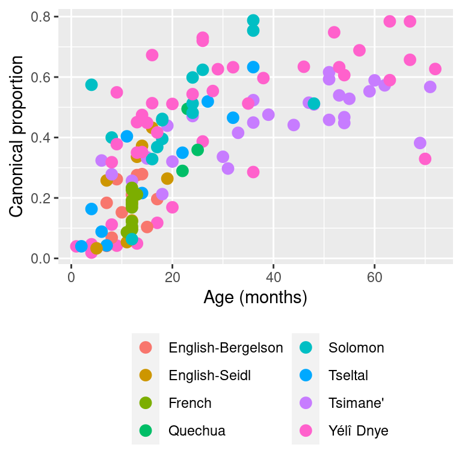

### Canonical proportion by age, separated by corpus

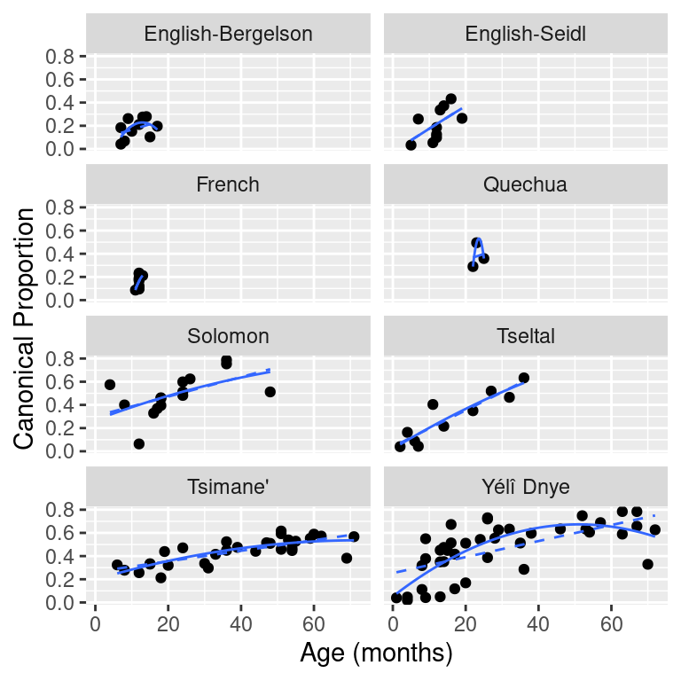

### Canonical proportion by age, colored by syllabic complexity

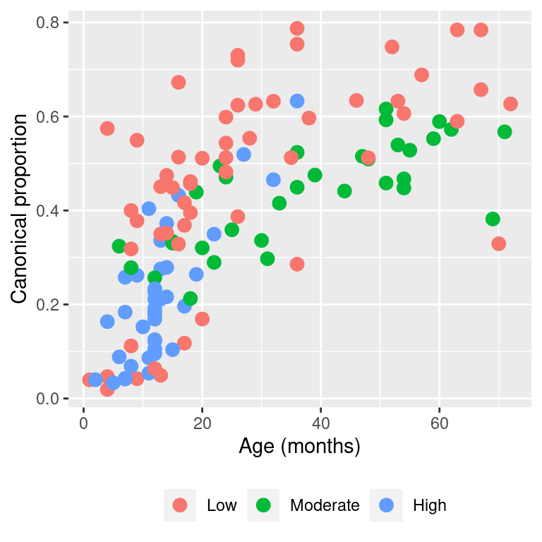

### Canonical proportion by age, colored by child sex

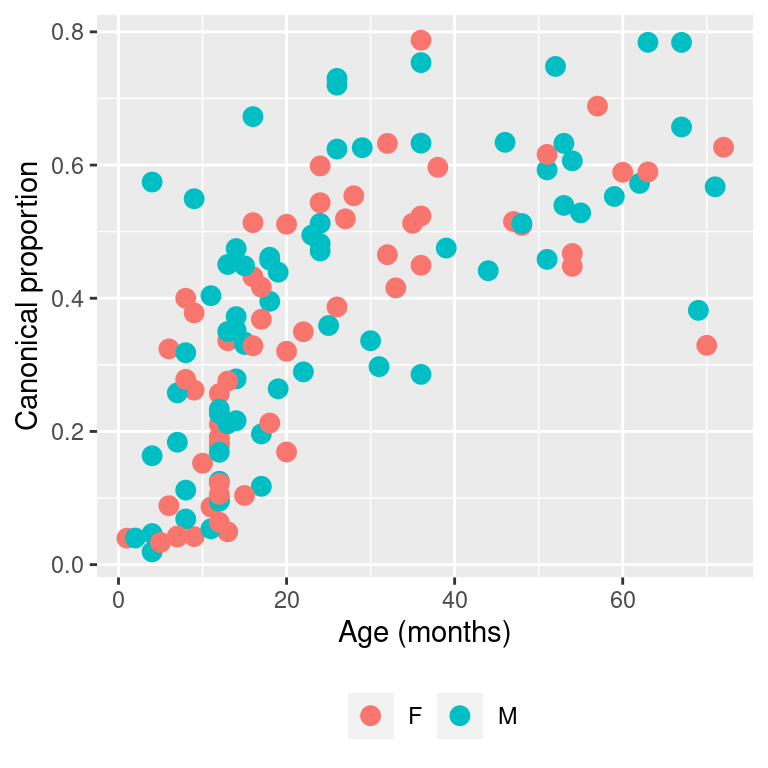